# Analysis on Storm Dataset

October 8, 2017

## Synopsis

*Questions*

Your data analysis must address the following questions:

*1. Across the United States, which types of events (as indicated in the EVTYPE variable) are most harmful with respect to population health?

*2. Across the United States, which types of events have the greatest economic consequences?

## Data Processing

1. Load the data

```r
rm(list = ls())
#set working directory
setwd("D:/Coursera/DS/Reproducible/DDS_RepR_w4")
getwd()
```

```
## [1] "D:/Coursera/DS/Reproducible/DDS_RepR_w4"
```

```r
if(!file.exists("data")) {
    dir.create("data")
}
#download and unzip, file handling

fileURL<-"https://d396qusza40orc.cloudfront.net/repdata%2Fdata%2FStormData.csv.bz2"
download.file(fileURL, destfile="./StormData.csv.bz2")
dt<-read.csv(paste(getwd(),"StormData.csv.bz2", sep="/"), stringsAsFactors = FALSE)
```

2. format and rename for convinence From the names of column, we’re interested in the crop and population damages, so we only subsect those data. Here I use `select()` and `filter()` to subsect the dataframe. Alternative could use `subset()`. Also, `%>%`is used as pipe coding style.

The list of them:

- `EVTYPE`: the event type,
- `BGN_DATE`: the date of the event,
- `FATALITIES`: the number of fatalities that resulted,
- `INJURIES`: the number of injuries that resulted,
- `PROPDMG`: an estimate for the amount of property damage,
- `PROPDMGEXP`: a “multiplier” extension for the amount in PROPDMG,
- `CROPDMG`: an estimate for the amount of crop damage,
- `CROPDMGEXP`: a “multiplier” extension for the amount in CROPDMG,
- `REMARKS`: remarks added by the person recording the data.

```r
names(dt)
```

```
##  [1] "STATE__"    "BGN_DATE"   "BGN_TIME"   "TIME_ZONE"  "COUNTY"
##  [6] "COUNTYNAME" "STATE"      "EVTYPE"     "BGN_RANGE"  "BGN_AZI"
## [11] "BGN_LOCATI" "END_DATE"   "END_TIME"   "COUNTY_END" "COUNTYENDN"
## [16] "END_RANGE"  "END_AZI"    "END_LOCATI" "LENGTH"     "WIDTH"
## [21] "F"          "MAG"        "FATALITIES" "INJURIES"   "PROPDMG"
## [26] "PROPDMGEXP" "CROPDMG"    "CROPDMGEXP" "WFO"        "STATEOFFIC"
## [31] "ZONENAMES"  "LATITUDE"   "LONGITUDE"  "LATITUDE_E" "LONGITUDE_"
## [36] "REMARKS"    "REFNUM"
```

```r
library("dplyr")
#only choose the above columns
dt_sel <- dt %>%
    select(EVTYPE, BGN_DATE, FATALITIES, INJURIES, PROPDMG, PROPDMGEXP,
           CROPDMG, CROPDMGEXP, REMARKS)
#format the date by as.Date()
date_f<- dt_sel$BGN_DATE %>%
    strsplit(" ") %>%   #separate by the " ": first element Date, second element time
    unlist() %>%        #strsplit output list
    matrix(nrow=dim(dt_sel)[1], byrow=TRUE)
date_f<-as.Date(date_f[,1],format="%m/%d/%Y") #format the dates
dt_sel$DATE<-date_f
dt_sel<-select(dt_sel,-BGN_DATE)  #remove the BGN_DATE, alternative is to overwrite this at the previous step
```

Let’s look at the following variables:

- `PROPDMG`: an estimate for the amount of property damage,
- `PROPDMGEXP`: a “multiplier” extension for the amount in PROPDMG,
- `CROPDMG`: an estimate for the amount of crop damage,
- `CROPDMGEXP`: a “multiplier” extension for the amount in CROPDMG

```r
unique(dt_sel$PROPDMGEXP)
```

```
##  [1] "K" "M" ""  "B" "m" "+" "0" "5" "6" "?" "4" "2" "3" "h" "7" "H" "-"
## [18] "1" "8"
```

```r
unique(dt_sel$CROPDMGEXP)
```

```
## [1] ""  "M" "K" "m" "B" "?" "0" "k" "2"
```

Both the `*EXP` has different characters standing for different multipliers. Here we interprate the symbols as followings:

`H/h` as 10<sup>2</sup> `K/k` as 10<sup>3</sup> `M/m` as 10<sup>6</sup> `B/b` as 10<sup>9</sup>

Here, we use `switch()` function to translate the characters into numerical variables.

```r
#use sapply to loop around to change the characters into factors
prop_factor <- sapply(dt_sel$PROPDMGEXP,
    function(x) {switch(x,  "k" = 1000, "K" = 1000,
                            "m" = 1000000, "M" = 1000000,
                            "B" = 1000000000, "b"= 1000000000,
                            "H"= 100, "h"=100, 1)})
#compare the factor to verify if the translation is correct
table(prop_factor)
```

```
## prop_factor
##      1    100   1000  1e+06  1e+09
## 466248      7 424665  11337     40
```

```r
table(dt_sel$PROPDMGEXP)
```

```
##
##             -      ?      +      0      1      2      3      4      5
## 465934      1      8      5    216     25     13      4      4     28
##      6      7      8      B      h      H      K      m      M
##      4      5      1     40      1      6 424665      7  11330
```

```r
crop_factor <- sapply(dt_sel$CROPDMGEXP,
    function(x) {switch(x,  "k" = 1000, "K" = 1000,
                            "m" = 1000000, "M" = 1000000,
                            "B" = 1000000000, "b"= 1000000000,
                            "H"= 100, "h"=100, 1)})
table(crop_factor)
```

```
## crop_factor
##      1   1000  1e+06  1e+09
## 618440 281853   1995      9
```

```r
table(dt_sel$CROPDMGEXP)
```

```
##
##             ?      0      2      B      k      K      m      M
## 618413      7     19      1      9     21 281832      1   1994
```

```r
#Multiply the numbers by the factors
dt_sel_f<-dt_sel %>%
    mutate(CROP_VAL=CROPDMG*crop_factor,PROP_VAL=PROPDMG*prop_factor )
```

Now, we finish the manipulation of the data, and begin to answer the two questions.

## Results

**1. Across the United States, which types of events (as indicated in the EVTYPE variable) are most harmful with respect to population health?**

```r
#change all the events to upper case
dt_sel_f$EVTYPE<-toupper(dt_sel_f$EVTYPE)
dt_sel_f %>%
    filter(EVTYPE!="?") %>% # filter out one event called "?"
    group_by(EVTYPE) %>%
    summarise(Death=sum(FATALITIES), Injury=sum(INJURIES), Property_value=sum(PROP_VAL), Crop_Value=sum(CROP_VAL))
```

```
## # A tibble: 897 x 5
##                   EVTYPE Death Injury Property_value Crop_Value
##                    <chr> <dbl>  <dbl>          <dbl>      <dbl>
##  1    HIGH SURF ADVISORY     0      0         200000          0
##  2         COASTAL FLOOD     0      0              0          0
##  3           FLASH FLOOD     0      0          50000          0
##  4             LIGHTNING     0      0              0          0
##  5             TSTM WIND     0      0        8100000          0
##  6       TSTM WIND (G45)     0      0           8000          0
##  7            WATERSPOUT     0      0              0          0
##  8                  WIND     0      0              0          0
##  9       ABNORMAL WARMTH     0      0              0          0
## 10        ABNORMALLY DRY     0      0              0          0
## # ... with 887 more rows
```

*one should be able to futher compact the list as a few events have similar names and referring to the same events*

One can further examine the top ten events in each category

```r
dt_sel_f %>%
    select(EVTYPE, FATALITIES) %>%
    group_by(EVTYPE) %>%
    summarise(Death=sum(FATALITIES)) %>%
    arrange(desc(Death)) %>%
    head(10)
```

```
## # A tibble: 10 x 2
##            EVTYPE Death
##             <chr> <dbl>
##  1        TORNADO  5633
##  2 EXCESSIVE HEAT  1903
##  3    FLASH FLOOD   978
##  4           HEAT   937
##  5      LIGHTNING   816
##  6      TSTM WIND   504
##  7          FLOOD   470
##  8    RIP CURRENT   368
##  9      HIGH WIND   248
## 10      AVALANCHE   224
```

From this list, one can see **TORNADO** is the most fatal event.

```r
dt_sel_f %>%
    select(EVTYPE, INJURIES) %>%
    group_by(EVTYPE) %>%
    summarise(Injury=sum(INJURIES)) %>%
    arrange(desc(Injury)) %>%
    head(10)
```

```
## # A tibble: 10 x 2
##               EVTYPE Injury
##                <chr>  <dbl>
##  1           TORNADO  91346
##  2         TSTM WIND   6957
##  3             FLOOD   6789
##  4    EXCESSIVE HEAT   6525
##  5         LIGHTNING   5230
##  6              HEAT   2100
##  7         ICE STORM   1975
##  8       FLASH FLOOD   1777
##  9 THUNDERSTORM WIND   1488
## 10              HAIL   1361
```

From this list, one can see **TORNADO** is the event with most injuries.

Let’s do a plot for this question.

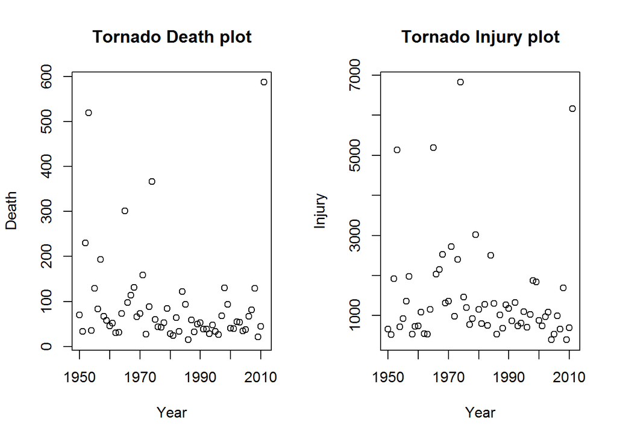

```r
dt_sel_f$YEAR<-as.character(format(dt_sel_f$DATE, "%Y"))
tornadoes <- dt_sel_f %>%
    filter(EVTYPE == "TORNADO") %>%
    group_by(YEAR) %>%
    summarize(Death = sum(FATALITIES), Injury = sum(INJURIES))

par(mfrow=c(1,2))
plot(tornadoes$YEAR,tornadoes$Death, xlab = "Year", ylab = "Death", main = "Tornado Death plot")
plot(tornadoes$YEAR,tornadoes$Injury,xlab = "Year", ylab = "Injury", main = "Tornado Injury plot")
```

**2. Across the United States, which types of events have the greatest economic consequences?**

Similar to the above plots, we can generate the table for CROP and PROPERTY DAMAGE VALUES

```r
#Property_value=sum(PROP_VAL), Crop_Value=sum(CROP_VAL)
dt_sel_f %>%
    select(EVTYPE, PROP_VAL) %>%
    group_by(EVTYPE) %>%
    summarise(Property_value=sum(PROP_VAL)) %>%
    arrange(desc(Property_value)) %>%
    head(10)
```

```
## # A tibble: 10 x 2
##               EVTYPE Property_value
##                <chr>          <dbl>
##  1             FLOOD   144657709807
##  2 HURRICANE/TYPHOON    69305840000
##  3           TORNADO    56937160779
##  4       STORM SURGE    43323536000
##  5       FLASH FLOOD    16140812067
##  6              HAIL    15732267543
##  7         HURRICANE    11868319010
##  8    TROPICAL STORM     7703890550
##  9      WINTER STORM     6688497251
## 10         HIGH WIND     5270046295
```

```r
dt_sel_f %>%
    select(EVTYPE, CROP_VAL) %>%
    group_by(EVTYPE) %>%
    summarise(Crop_Value=sum(CROP_VAL)) %>%
    arrange(desc(Crop_Value)) %>%
    head(10)
```

```
## # A tibble: 10 x 2
##               EVTYPE  Crop_Value
##                <chr>       <dbl>
##  1           DROUGHT 13972566000
##  2             FLOOD  5661968450
##  3       RIVER FLOOD  5029459000
##  4         ICE STORM  5022113500
##  5              HAIL  3025954473
##  6         HURRICANE  2741910000
##  7 HURRICANE/TYPHOON  2607872800
##  8       FLASH FLOOD  1421317100
##  9      EXTREME COLD  1312973000
## 10      FROST/FREEZE  1094186000
```

In term of property value, FLOOD is the most costly one. In term of the crops values, DROUGH is the one.

## Data source

https://d396qusza40orc.cloudfront.net/repdata%2Fdata%2FStormData.csv.bz2